# Project: Investigate a Dataset (The Movie Database "TMDb")

- Introduction
- Data Wrangling
- Exploratory Data Analysis
- Conclusions

## Introduction

This project is about analyzing a database that contains data of more than 10,000 movies. The database is called The Movie Database (TMDb). The columns, or features, in this database are described as follows:

- id : A unique identifier for each movie in the database.
- imdb_id : A unique identifier for the movie on Internet Movie Database (IMDb), the world's most popular and authoritative source for movie, TV and celebrity content.
- popularity : A numerical index representing the popularity of the movie.
- budget : The amount of money spent on the movie.
- revenue : The total revenue of the movie.
- original_title : The title of the movie before translation or adaptation.
- cast : The group of actors who made up the movie.
- homepage : A link to the homepage for the movie website.
- director : The movie's director.
- tagline : The tagline of the movie.
- keywords : Keywords that are associated with the movie.
- overview : A brief description of the movie.
- runtime : Total running time of the movie in minutes.
- genres : Category of the movie (Action, Drama, .. etc).
- production_companies : The companies that produced the movie.
- release_date : The date on which the movie was released to the public.
- vote_count : Number of voters.
- vote_average : The average rating of the movie.
- release_year : The year on which the movie was released.
- budget_adj : Movie's budget in terms of US dollar value in 2010.
- revenue_adj : Movie's revenue in terms of US dollar value in 2010.

This database can be explored in many ways. There are many insights that can be derived from it. However, in this proejct, the exploration will be constrained around the following research questions:

RQ1: Which year had the highest movie releases?  
RQ2: In which month were most movie releases of all time?  
RQ3: What are the most popular movie genres of all time?  
RQ4: What are the 10 most profitable movies of all time?  
RQ5: How do budget and runtime affect the popularity of the movie?  
RQ6: How does the popularity of the movie affect revenue, profit, vote count and average vote?

## Data Wrangling

### General Properties

```python
#Importing required libraries

import numpy as np
import pandas as pd
import seaborn as sns
import matplotlib.pyplot as plt
import warnings
import matplotlib
matplotlib.rcParams["figure.dpi"] = 300
matplotlib.rcParams['savefig.dpi'] = 300
plt.style.use("seaborn-whitegrid")
warnings.filterwarnings('ignore')
```

```python
#Reading the CSV file
df = pd.read_csv("tmdb-movies.csv")
df.head(5)
```

|  | id | imdb_id | popularity | budget | revenue | original_title | cast | homepage | director | tagline | ... | overview | runtime | genres | production_companies | release_date | vote_count | vote_average | release_year | budget_adj | revenue_adj |
| --- | --- | --- | --- | --- | --- | --- | --- | --- | --- | --- | --- | --- | --- | --- | --- | --- | --- | --- | --- | --- | --- |
| 0 | 135397 | tt0369610 | 32.985763 | 150000000 | 1513528810 | Jurassic World | Chris Pratt\|Bryce Dallas Howard\|Irrfan Khan\|Vi... | http://www.jurassicworld.com/ | Colin Trevorrow | The park is open. | ... | Twenty-two years after the events of Jurassic ... | 124 | Action\|Adventure\|Science Fiction\|Thriller | Universal Studios\|Amblin Entertainment\|Legenda... | 6/9/15 | 5562 | 6.5 | 2015 | 1.379999e+08 | 1.392446e+09 |
| 1 | 76341 | tt1392190 | 28.419936 | 150000000 | 378436354 | Mad Max: Fury Road | Tom Hardy\|Charlize Theron\|Hugh Keays-Byrne\|Nic... | http://www.madmaxmovie.com/ | George Miller | What a Lovely Day. | ... | An apocalyptic story set in the furthest reach... | 120 | Action\|Adventure\|Science Fiction\|Thriller | Village Roadshow Pictures\|Kennedy Miller Produ... | 5/13/15 | 6185 | 7.1 | 2015 | 1.379999e+08 | 3.481613e+08 |
| 2 | 262500 | tt2908446 | 13.112507 | 110000000 | 295238201 | Insurgent | Shailene Woodley\|Theo James\|Kate Winslet\|Ansel... | http://www.thedivergentseries.movie/#insurgent | Robert Schwentke | One Choice Can Destroy You | ... | Beatrice Prior must confront her inner demons ... | 119 | Adventure\|Science Fiction\|Thriller | Summit Entertainment\|Mandeville Films\|Red Wago... | 3/18/15 | 2480 | 6.3 | 2015 | 1.012000e+08 | 2.716190e+08 |
| 3 | 140607 | tt2488496 | 11.173104 | 200000000 | 2068178225 | Star Wars: The Force Awakens | Harrison Ford\|Mark Hamill\|Carrie Fisher\|Adam D... | http://www.starwars.com/films/star-wars-episod... | J.J. Abrams | Every generation has a story. | ... | Thirty years after defeating the Galactic Empi... | 136 | Action\|Adventure\|Science Fiction\|Fantasy | Lucasfilm\|Truenorth Productions\|Bad Robot | 12/15/15 | 5292 | 7.5 | 2015 | 1.839999e+08 | 1.902723e+09 |
| 4 | 168259 | tt2820852 | 9.335014 | 190000000 | 1506249360 | Furious 7 | Vin Diesel\|Paul Walker\|Jason Statham\|Michelle ... | http://www.furious7.com/ | James Wan | Vengeance Hits Home | ... | Deckard Shaw seeks revenge against Dominic Tor... | 137 | Action\|Crime\|Thriller | Universal Pictures\|Original Film\|Media Rights ... | 4/1/15 | 2947 | 7.3 | 2015 | 1.747999e+08 | 1.385749e+09 |

5 rows × 21 columns

```python
#Looking at information about the dataset
df.info()
```

```
<class 'pandas.core.frame.DataFrame'>
RangeIndex: 10866 entries, 0 to 10865
Data columns (total 21 columns):
 #   Column                Non-Null Count  Dtype
---  ------                --------------  -----
 0   id                    10866 non-null  int64
 1   imdb_id               10856 non-null  object
 2   popularity            10866 non-null  float64
 3   budget                10866 non-null  int64
 4   revenue               10866 non-null  int64
 5   original_title        10866 non-null  object
 6   cast                  10790 non-null  object
 7   homepage              2936 non-null   object
 8   director              10822 non-null  object
 9   tagline               8042 non-null   object
 10  keywords              9373 non-null   object
 11  overview              10862 non-null  object
 12  runtime               10866 non-null  int64
 13  genres                10843 non-null  object
 14  production_companies  9836 non-null   object
 15  release_date          10866 non-null  object
 16  vote_count            10866 non-null  int64
 17  vote_average          10866 non-null  float64
 18  release_year          10866 non-null  int64
 19  budget_adj            10866 non-null  float64
 20  revenue_adj           10866 non-null  float64
dtypes: float64(4), int64(6), object(11)
memory usage: 1.7+ MB
```

```python
#Descriptive statistics about the dataset
df.describe()
```

|  | id | popularity | budget | revenue | runtime | vote_count | vote_average | release_year | budget_adj | revenue_adj |
| --- | --- | --- | --- | --- | --- | --- | --- | --- | --- | --- |
| count | 10866.000000 | 10866.000000 | 1.086600e+04 | 1.086600e+04 | 10866.000000 | 10866.000000 | 10866.000000 | 10866.000000 | 1.086600e+04 | 1.086600e+04 |
| mean | 66064.177434 | 0.646441 | 1.462570e+07 | 3.982332e+07 | 102.070863 | 217.389748 | 5.974922 | 2001.322658 | 1.755104e+07 | 5.136436e+07 |
| std | 92130.136561 | 1.000185 | 3.091321e+07 | 1.170035e+08 | 31.381405 | 575.619058 | 0.935142 | 12.812941 | 3.430616e+07 | 1.446325e+08 |
| min | 5.000000 | 0.000065 | 0.000000e+00 | 0.000000e+00 | 0.000000 | 10.000000 | 1.500000 | 1960.000000 | 0.000000e+00 | 0.000000e+00 |
| 25% | 10596.250000 | 0.207583 | 0.000000e+00 | 0.000000e+00 | 90.000000 | 17.000000 | 5.400000 | 1995.000000 | 0.000000e+00 | 0.000000e+00 |
| 50% | 20669.000000 | 0.383856 | 0.000000e+00 | 0.000000e+00 | 99.000000 | 38.000000 | 6.000000 | 2006.000000 | 0.000000e+00 | 0.000000e+00 |
| 75% | 75610.000000 | 0.713817 | 1.500000e+07 | 2.400000e+07 | 111.000000 | 145.750000 | 6.600000 | 2011.000000 | 2.085325e+07 | 3.369710e+07 |
| max | 417859.000000 | 32.985763 | 4.250000e+08 | 2.781506e+09 | 900.000000 | 9767.000000 | 9.200000 | 2015.000000 | 4.250000e+08 | 2.827124e+09 |

```python
#Checking if there are null values in the dataset
df.isnull().sum()
```

```
id                         0
imdb_id                   10
popularity                 0
budget                     0
revenue                    0
original_title             0
cast                      76
homepage                7930
director                  44
tagline                 2824
keywords                1493
overview                   4
runtime                    0
genres                    23
production_companies    1030
release_date               0
vote_count                 0
vote_average               0
release_year               0
budget_adj                 0
revenue_adj                0
dtype: int64
```

There are columns with large number of null values such as homepage and tagline. These columns are not needed in our analysis anyways. Hence, they will be dropped in the data cleaning part.

### Data Cleaning

#### Duplicated rows

```python
#Checking if there are any duplicated rows
print(f"Number of dublicated rows : {sum(df.duplicated())}")
print(df.shape)
```

```
Number of dublicated rows : 1
(10866, 21)
```

Only one duplicated row is found. Dropping this row would be the best decision to make.

```python
#Dropping duplicated rows
df = df.drop_duplicates()
print(df.shape)
```

```
(10865, 21)
```

The duplicated row has been dropped sucessfully.

#### Unnecessary Columns

Some columns are not necessary for our analysis. Therefore, they will be dropped.

```python
df = df.drop(['imdb_id','homepage', 'director', 'tagline', 'keywords','overview','production_companies','budget_adj','revenue_adj'],axis =1)
df.shape
```

```
(10865, 12)
```

#### Data Transformation

The 'release date' column is going to be transformed to datetime datatype so that we can deal with it more easily.

```python
df['release_date']
```

```
0          6/9/15
1         5/13/15
2         3/18/15
3        12/15/15
4          4/1/15
           ...
10861     6/15/66
10862    12/21/66
10863      1/1/66
10864     11/2/66
10865    11/15/66
Name: release_date, Length: 10865, dtype: object
```

```python
df['release_date'] = pd.to_datetime(df['release_date'])
df['release_date']
```

```
0       2015-06-09
1       2015-05-13
2       2015-03-18
3       2015-12-15
4       2015-04-01
           ...
10861   2066-06-15
10862   2066-12-21
10863   2066-01-01
10864   2066-11-02
10865   2066-11-15
Name: release_date, Length: 10865, dtype: datetime64[ns]
```

#### Movies with runtime that is less than or equal to zero

There are no real movies with zero or negative runtime. If there exists such a movie in the dataset, there must be something wrong. Therefore, any row with zero or negative runtime will be dropped.

```python
#Finding rows with zero or negative runtime
print(df[df['runtime'] <= 0].shape)
print(df[df['runtime'] == 0].shape)
print(df.shape)
df[df['runtime'] <= 0].head(5)
```

```
(31, 12)
(31, 12)
(10865, 12)
```

|  | id | popularity | budget | revenue | original_title | cast | runtime | genres | release_date | vote_count | vote_average | release_year |
| --- | --- | --- | --- | --- | --- | --- | --- | --- | --- | --- | --- | --- |
| 92 | 370687 | 1.876037 | 0 | 0 | Mythica: The Necromancer | Melanie Stone\|Adam Johnson\|Kevin Sorbo\|Nicola ... | 0 | Fantasy\|Action\|Adventure | 2015-12-19 | 11 | 5.4 | 2015 |
| 334 | 361931 | 0.357654 | 0 | 0 | Ronaldo | Cristiano Ronaldo | 0 | Documentary | 2015-11-09 | 80 | 6.5 | 2015 |
| 410 | 339342 | 0.097514 | 0 | 0 | Anarchy Parlor | Robert LaSardo\|Jordan James Smith\|Sara Fabel\|T... | 0 | Horror | 2015-01-01 | 15 | 5.6 | 2015 |
| 445 | 353345 | 0.218528 | 0 | 0 | The Exorcism of Molly Hartley | Sarah Lind\|Devon Sawa\|Gina Holden\|Peter MacNei... | 0 | Horror | 2015-10-09 | 52 | 5.0 | 2015 |
| 486 | 333653 | 0.176744 | 0 | 0 | If There Be Thorns | Heather Graham\|Jason Lewis\|Rachael Carpani\|Mas... | 0 | TV Movie\|Drama | 2015-04-05 | 11 | 5.4 | 2015 |

There are 31 movies in the dataset with zero runtime. Also, we notice that some of these rows have zero values in the budget and revenue columns. Hence, this is another reason for dropping these rows.

```python
#Dropping these movies from the dataset
Index_Error = df[df['runtime'] <= 0].index
df.drop(Index_Error, inplace=True)
df.shape
```

```
(10834, 12)
```

## Exploratory Data Analysis

### Research Question 1 (Which year had the highest movie releases?)

```python
#First step is to count the number of values in each year
Releases_Per_Year = df['release_year'].value_counts().sort_index()
#Viewing the last five values
Releases_Per_Year[-5:]
```

```
2011    537
2012    586
2013    654
2014    697
2015    622
Name: release_year, dtype: int64
```

After we found the number of releases per year, next step would be to plot our finding in a line plot.

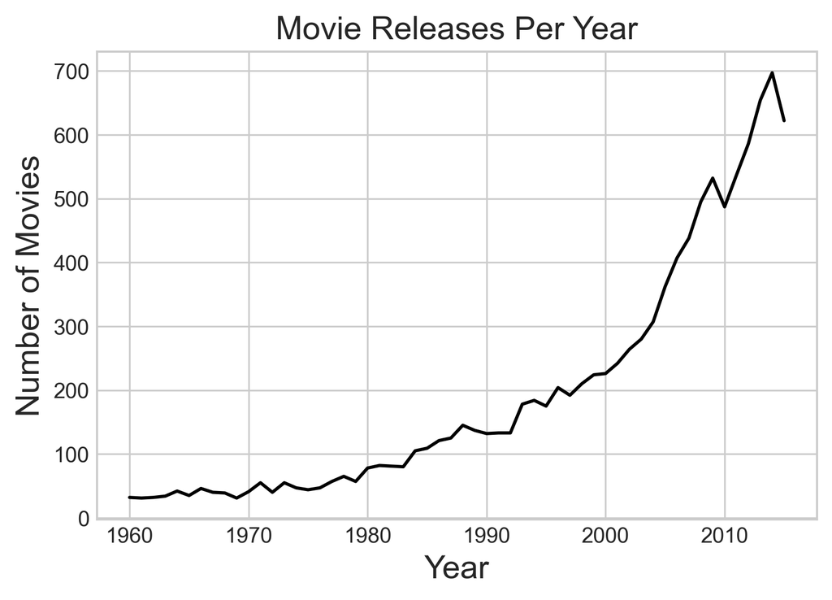

```python
plt.plot(Releases_Per_Year, 'k-')
plt.title("Movie Releases Per Year", fontsize = 15)
plt.xlabel("Year", fontsize = 15)
plt.ylabel("Number of Movies", fontsize = 15)
```

Clearly, we can see that the year with the highest number of movie releases is 2014 with 697 movie releases. Year 2013 comes in the second place with 654 movie releases, year 2015 is in the third place with 622 movie releases.

### Research Question 2 (In which month were most movie releases of all time?)

```python
#Creating a column for releasing month
df['release_month'] = df['release_date'].dt.month
df.head(5)
```

|  | id | popularity | budget | revenue | original_title | cast | runtime | genres | release_date | vote_count | vote_average | release_year | release_month |
| --- | --- | --- | --- | --- | --- | --- | --- | --- | --- | --- | --- | --- | --- |
| 0 | 135397 | 32.985763 | 150000000 | 1513528810 | Jurassic World | Chris Pratt\|Bryce Dallas Howard\|Irrfan Khan\|Vi... | 124 | Action\|Adventure\|Science Fiction\|Thriller | 2015-06-09 | 5562 | 6.5 | 2015 | 6 |
| 1 | 76341 | 28.419936 | 150000000 | 378436354 | Mad Max: Fury Road | Tom Hardy\|Charlize Theron\|Hugh Keays-Byrne\|Nic... | 120 | Action\|Adventure\|Science Fiction\|Thriller | 2015-05-13 | 6185 | 7.1 | 2015 | 5 |
| 2 | 262500 | 13.112507 | 110000000 | 295238201 | Insurgent | Shailene Woodley\|Theo James\|Kate Winslet\|Ansel... | 119 | Adventure\|Science Fiction\|Thriller | 2015-03-18 | 2480 | 6.3 | 2015 | 3 |
| 3 | 140607 | 11.173104 | 200000000 | 2068178225 | Star Wars: The Force Awakens | Harrison Ford\|Mark Hamill\|Carrie Fisher\|Adam D... | 136 | Action\|Adventure\|Science Fiction\|Fantasy | 2015-12-15 | 5292 | 7.5 | 2015 | 12 |
| 4 | 168259 | 9.335014 | 190000000 | 1506249360 | Furious 7 | Vin Diesel\|Paul Walker\|Jason Statham\|Michelle ... | 137 | Action\|Crime\|Thriller | 2015-04-01 | 2947 | 7.3 | 2015 | 4 |

```python
#Counting the number of movies per month
Releases_Per_Month = df['release_month'].value_counts().sort_index()
Releases_Per_Month
```

```
1      914
2      689
3      820
4      795
5      806
6      823
7      798
8      917
9     1330
10    1148
11     811
12     983
Name: release_month, dtype: int64
```

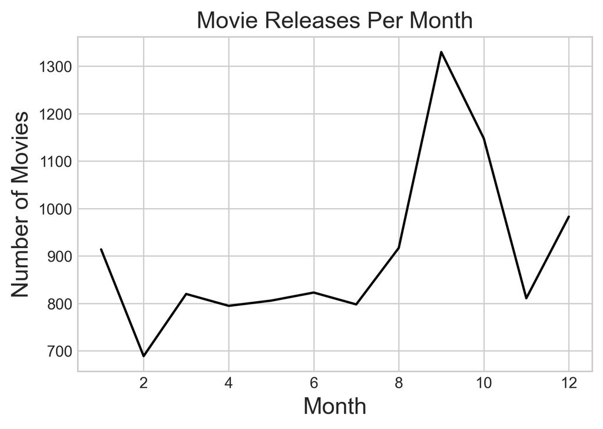

```python
#Plotting number of releases per month
plt.plot(Releases_Per_Month, 'k-')
plt.title("Movie Releases Per Month", fontsize = 15)
plt.xlabel("Month", fontsize = 15)
plt.ylabel("Number of Movies", fontsize = 15)
```

September has the highest number of movie releases with 1330 movie releases. Then, October is the second highest month in terms of movie releases with 1148 movie releases.

### Research Question 3 (What are the most popular movie genres of all time?)

```python
#Separating the categories in the genres column
Splitted_Genres = df["genres"].str.get_dummies(sep = '|')
Splitted_Genres.head(5)
```

|  | Action | Adventure | Animation | Comedy | Crime | Documentary | Drama | Family | Fantasy | Foreign | History | Horror | Music | Mystery | Romance | Science Fiction | TV Movie | Thriller | War | Western |
| --- | --- | --- | --- | --- | --- | --- | --- | --- | --- | --- | --- | --- | --- | --- | --- | --- | --- | --- | --- | --- |
| 0 | 1 | 1 | 0 | 0 | 0 | 0 | 0 | 0 | 0 | 0 | 0 | 0 | 0 | 0 | 0 | 1 | 0 | 1 | 0 | 0 |
| 1 | 1 | 1 | 0 | 0 | 0 | 0 | 0 | 0 | 0 | 0 | 0 | 0 | 0 | 0 | 0 | 1 | 0 | 1 | 0 | 0 |
| 2 | 0 | 1 | 0 | 0 | 0 | 0 | 0 | 0 | 0 | 0 | 0 | 0 | 0 | 0 | 0 | 1 | 0 | 1 | 0 | 0 |
| 3 | 1 | 1 | 0 | 0 | 0 | 0 | 0 | 0 | 1 | 0 | 0 | 0 | 0 | 0 | 0 | 1 | 0 | 0 | 0 | 0 |
| 4 | 1 | 0 | 0 | 0 | 1 | 0 | 0 | 0 | 0 | 0 | 0 | 0 | 0 | 0 | 0 | 0 | 0 | 1 | 0 | 0 |

```python
#Counting the frequency of each category and sorting the results
df_Genres = Splitted_Genres.sum().sort_values(0).loc[::-1].reset_index()
df_Genres.set_axis(['Genre', 'Number_of_Movies'], axis='columns', inplace=True)
df_Genres
```

|  | Genre | Number_of_Movies |
| --- | --- | --- |
| 0 | Drama | 4751 |
| 1 | Comedy | 3782 |
| 2 | Thriller | 2905 |
| 3 | Action | 2382 |
| 4 | Romance | 1705 |
| 5 | Horror | 1629 |
| 6 | Adventure | 1470 |
| 7 | Crime | 1353 |
| 8 | Family | 1229 |
| 9 | Science Fiction | 1228 |
| 10 | Fantasy | 915 |
| 11 | Mystery | 808 |
| 12 | Animation | 699 |
| 13 | Documentary | 517 |
| 14 | Music | 401 |
| 15 | History | 334 |
| 16 | War | 270 |
| 17 | Foreign | 187 |
| 18 | Western | 165 |
| 19 | TV Movie | 164 |

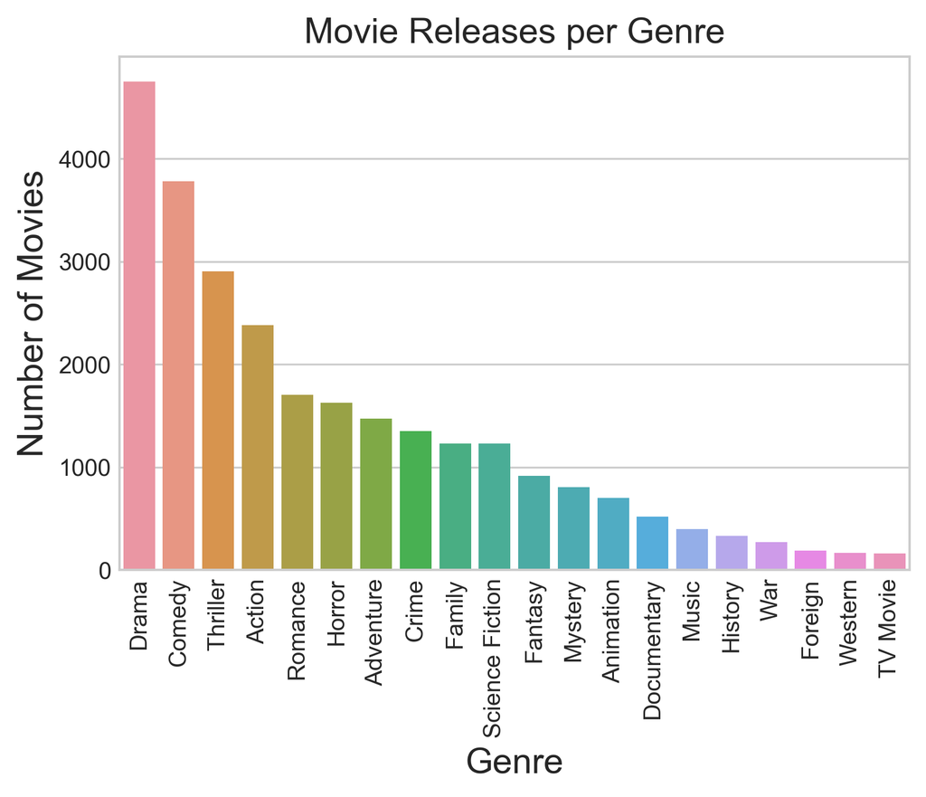

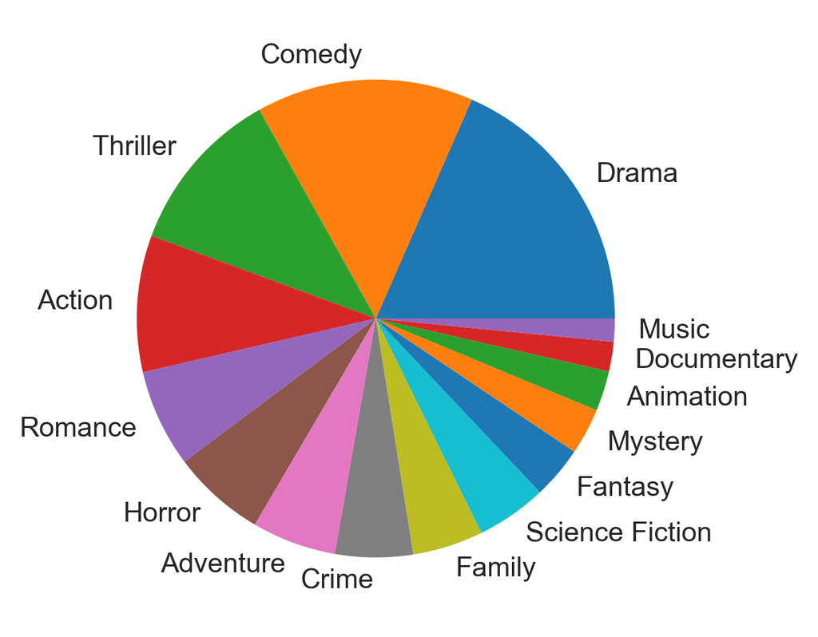

```python
#Plotting the findings using bar chart and pie chart
sns.barplot(x='Genre', y='Number_of_Movies',data=df_Genres)
plt.xticks(rotation=90)
plt.title("Movie Releases per Genre",fontsize=15)
plt.xlabel('Genre',fontsize=15)
plt.ylabel("Number of Movies",fontsize= 15)
plt.show()
plt.pie(df_Genres['Number_of_Movies'].head(15), labels = df_Genres['Genre'].head(15))
plt.show()
```

Results show that Drama is the most popular genre, or category. Then, Comedy, Thriller and Action come next.

### Research Question 4 (What are the 10 most profitable movies of all time?)

```python
#Introducing Profit Column
df['profit'] = df['revenue'] - df['budget']

#Sorting movies based on profit
Sorted_Profit = df.sort_values("profit").loc[::-1].reset_index()
#Printing the 3 most profitable movies
Sorted_Profit.head(3)
```

|  | index | id | popularity | budget | revenue | original_title | cast | runtime | genres | release_date | vote_count | vote_average | release_year | release_month | profit |
| --- | --- | --- | --- | --- | --- | --- | --- | --- | --- | --- | --- | --- | --- | --- | --- |
| 0 | 1386 | 19995 | 9.432768 | 237000000 | 2781505847 | Avatar | Sam Worthington\|Zoe Saldana\|Sigourney Weaver\|S... | 162 | Action\|Adventure\|Fantasy\|Science Fiction | 2009-12-10 | 8458 | 7.1 | 2009 | 12 | 2544505847 |
| 1 | 3 | 140607 | 11.173104 | 200000000 | 2068178225 | Star Wars: The Force Awakens | Harrison Ford\|Mark Hamill\|Carrie Fisher\|Adam D... | 136 | Action\|Adventure\|Science Fiction\|Fantasy | 2015-12-15 | 5292 | 7.5 | 2015 | 12 | 1868178225 |
| 2 | 5231 | 597 | 4.355219 | 200000000 | 1845034188 | Titanic | Kate Winslet\|Leonardo DiCaprio\|Frances Fisher\|... | 194 | Drama\|Romance\|Thriller | 1997-11-18 | 4654 | 7.3 | 1997 | 11 | 1645034188 |

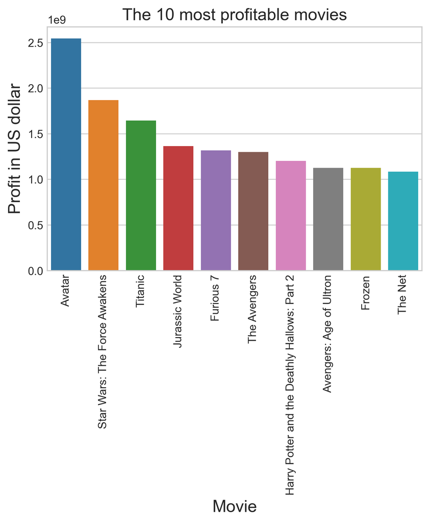

```python
#Plotting our finding using a bar chart
sns.barplot(x='original_title', y='profit',data=Sorted_Profit.head(10))
plt.xticks(rotation=90)
plt.title("The 10 most profitable movies",fontsize=15)
plt.xlabel('Movie',fontsize=15)
plt.ylabel("Profit in US dollar",fontsize= 15)
```

The most profitable movie is Avatar, then, the second one is Start Wars, and Titanic is the thrid.

### Research Question 5 (How do budget and runtime affect the popularity of the movie?)

First of all, two functions are defined to avoid code repetition. These functions are going to be used for RQ5 and RQ6.

```python
def scatter_plot(X,Y):
    plt.scatter(df[X], df[Y])
    plt.title(Y.capitalize() + ' VS ' + X.capitalize())
    plt.xlabel(X.capitalize())
    plt.ylabel(Y.capitalize())
    plt.show()

def reg_scatter_plot(X,Y):
    print("The correlation between", X, "and",  Y, "is :", df.corr().loc[X,Y])
    ax = sns.regplot(x = df[X], y = df[Y])
    ax.set_title(Y.capitalize() + ' VS ' + X.capitalize())
    ax.set_xlabel(X.capitalize())
    ax.set_ylabel(Y.capitalize())
```

```
The correlation between budget and popularity is : 0.5452864970129799
```

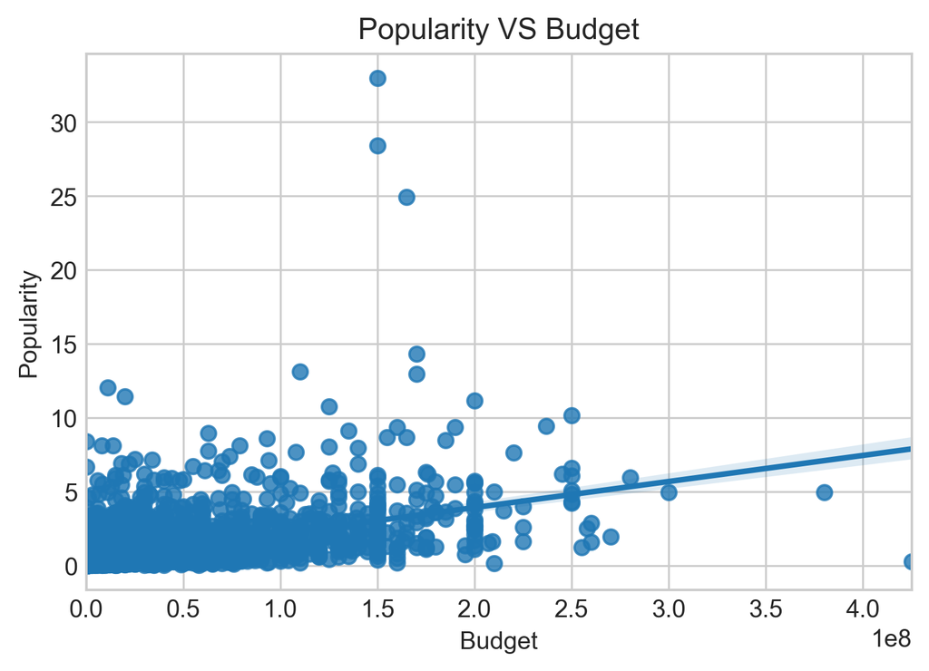

```python
reg_scatter_plot('budget', 'popularity')
```

The budget has an impact on the popularity of the movie. Movies with larger budgets tend to be more popular.

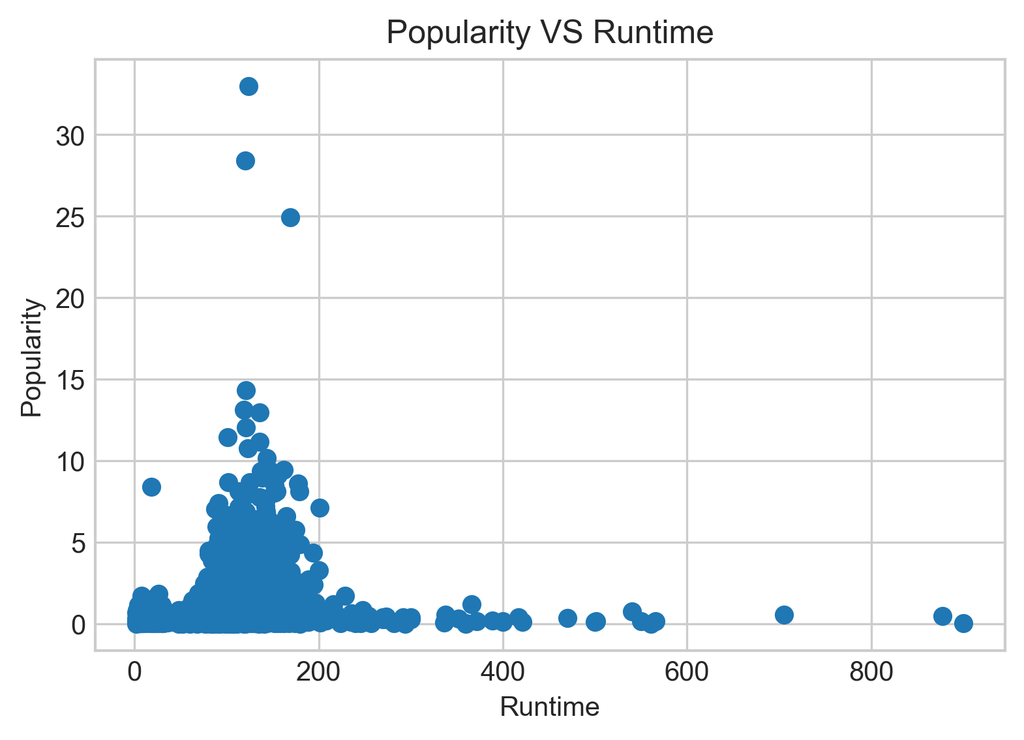

```python
scatter_plot('runtime', 'popularity')
```

```python
Runtime_analysis = df[(df['popularity'] > 4)]
Runtime_analysis.describe()
```

|  | id | popularity | budget | revenue | runtime | vote_count | vote_average | release_year | release_month | profit |
| --- | --- | --- | --- | --- | --- | --- | --- | --- | --- | --- |
| count | 137.000000 | 137.000000 | 1.370000e+02 | 1.370000e+02 | 137.000000 | 137.000000 | 137.000000 | 137.000000 | 137.000000 | 1.370000e+02 |
| mean | 87572.357664 | 6.637487 | 1.101223e+08 | 5.616883e+08 | 127.788321 | 3485.554745 | 7.116058 | 2007.649635 | 7.189781 | 4.515661e+08 |
| std | 94689.244832 | 3.912229 | 7.901703e+07 | 4.510066e+08 | 26.022171 | 1749.454604 | 0.706819 | 9.678350 | 3.277671 | 4.025823e+08 |
| min | 11.000000 | 4.008188 | 0.000000e+00 | 0.000000e+00 | 18.000000 | 11.000000 | 5.200000 | 1972.000000 | 1.000000 | 0.000000e+00 |
| 25% | 680.000000 | 4.780419 | 4.000000e+07 | 2.139288e+08 | 111.000000 | 2349.000000 | 6.600000 | 2003.000000 | 5.000000 | 1.478636e+08 |
| 50% | 57158.000000 | 5.704860 | 1.030000e+08 | 4.633601e+08 | 127.000000 | 3254.000000 | 7.300000 | 2012.000000 | 7.000000 | 3.546404e+08 |
| 75% | 157336.000000 | 6.907148 | 1.650000e+08 | 8.169693e+08 | 143.000000 | 4223.000000 | 7.600000 | 2014.000000 | 10.000000 | 6.610000e+08 |
| max | 318846.000000 | 32.985763 | 3.800000e+08 | 2.781506e+09 | 201.000000 | 9767.000000 | 8.400000 | 2015.000000 | 12.000000 | 2.544506e+09 |

The runtime of most popular movies is roughly between 110 and 140 minutes. The runtime has an impact on the popularity of the movie since people do not prefer long movies as per our finding.

### Research Question 6 (How does the popularity of the movie affect revenue, profit, vote count and average vote?)

```
The correlation between popularity and revenue is : 0.6633246595035992
```

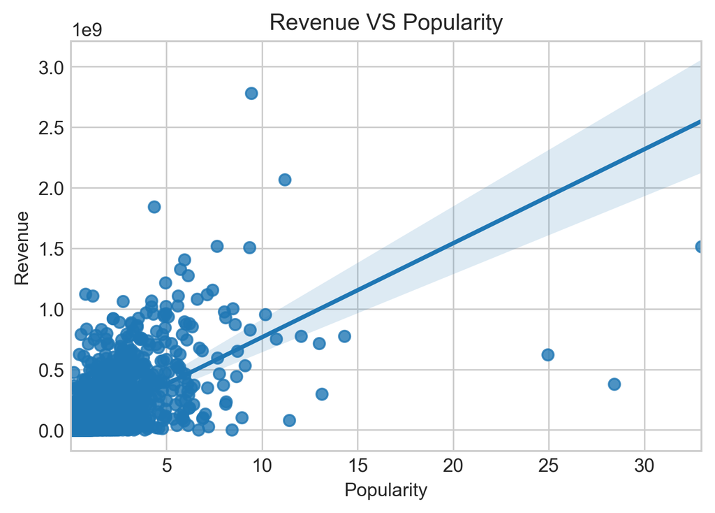

```python
reg_scatter_plot('popularity', 'revenue')
```

```
The correlation between popularity and profit is : 0.6289998405691876
```

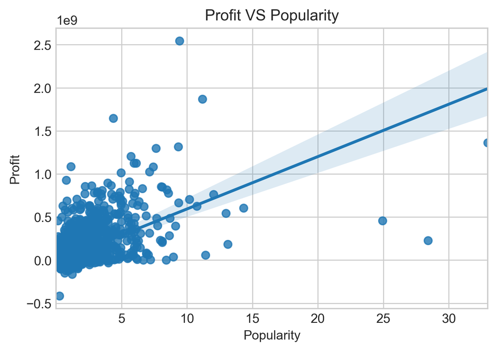

```python
reg_scatter_plot('popularity', 'profit')
```

```
The correlation between popularity and vote_count is : 0.8008766768514183
```

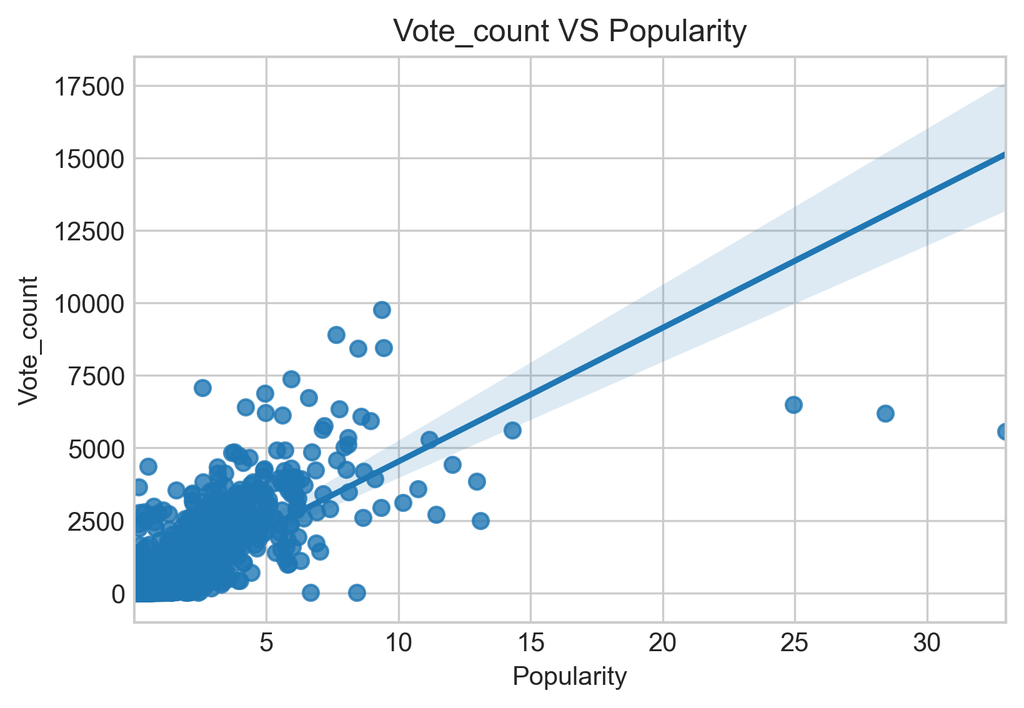

```python
reg_scatter_plot('popularity', 'vote_count')
```

```
The correlation between popularity and vote_average is : 0.2093103706727612
```

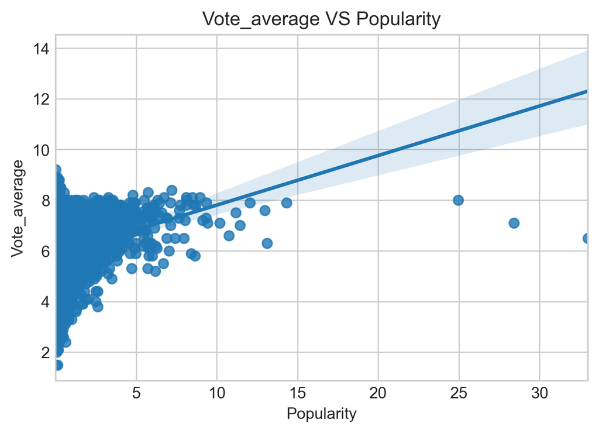

```python
reg_scatter_plot('popularity', 'vote_average')
```

There is a positive correlation between popularity and revenue, profit, vote count and average vote.

More popular movies tend to earn more profit, and this agrees with the common sense. Also, more popular movies tend to have higher number of voters, which is logical. The correlation between the popularity and average vote is positive but weak. That means more popular movies may not be highly rated.

## Limitations

There are some threats of validity affecting the validity of our conclusions:

- The dataset is not up-to-date and may not contain all movies.
- The dropped rows could have an impact on our results. For example, it may happen that one of the rows that were dropped contains a movie that has higher profit than Avatar movie that was reported as the most profitable movie. Hence, our conclusion that Avatar movie is the most profitable movie of all time could be wrong.